# Symulacja i wizualizacja strategii w grze SuperFarmer - faza 2

Agnieszka Ciepielewska i Ewelina Karbowiak

9 listopada 2016

**Abstract** Celem pierwszej fazy projektu dotyczącego symulacji i wizualizacji strategii w grze SuperFarmer jest stworzenie strategii gry i oszacowanie jaki jest rozkład czasu gry przyjętej strategii.

## Strategia gry

Nasza strategia gry opiera się na uczeniu maszynowym. W pierwszej kolejności stworzyłyśmy kod, który gra w grę SuperFarmer czysto losowo i dodatkowo skorzystałyśmy z dwóch strategii zaproponowanych przez naszych kolegów.

- Strategia I - Domink Ambroziak, Anna Dymowska, Adam Król [kliknij po więcej informacji o strategii](https://github.com/pbiecek/ProgramowanieWizualizacja/blob/master/MIMUW_2017/Projekty/Faza1/Faza1-Amb%2CDym%2CKrol.Rmd)
- Strategia II - Marianna Dzik, Piotr Radziński [kliknij po więcej informacji o strategii](https://github.com/pbiecek/ProgramowanieWizualizacja/blob/master/MIMUW_2017/Projekty/Faza1/Superfarmer_M_Dzik_P_Radzinski.html)

W kolejnym kroku wygenerowałyśmy dużą liczbę danych z wielu tur gier losowych, a następnie za pomocą modelu **random forest** zbudowałyśmy model uczenia maszynowego. Dzięki tej metodzie dla danego stanu stada i możliwych ruchów przewidujemy, którym ruchem najszybciej wygramy.

## Random forest

**Drzewo decyzyjne** jest to metoda wspomagająca proces decyzyjny. Składa się z węzłów - decyzji i stanów natury oraz gałęzi, czyli możliwych wariantów. Drzewa decyzyjne stosuje się w celu rozwiązania problemu decyzyjnego lub stworzenia jego planu. W uczeniu maszynowym z ich pomocą zdobywa się wiedzę z zestawu przykładów.

**Las losowy** jest zbiorem drzew decyzyjnych. Każde drzewo decyzyjne zwraca decyzję dotyczącą danej obserwacji. Są one traktowane jako głosy. Las losowy jako wynik zwraca decyzję, która otrzymała najwięcej głosów.

> randomForest(x, y=NULL, xtest=NULL, ytest=NULL, ntree=500, mtry)
- x - macierz opisująca zbiór uczący
- y - wektor wartości zmiennej objaśnianej dla zbioru uczącego
- xtest - macierz opisująca zbiór uczący, zawierająca dane dla zbioru testowego
- ytest - wektor wartości zmiennej objaśnianej dla zbioru testowego
- ntree - liczba drzew
- mtry - liczba zmiennych wybieranych losowo do stworzenia drzewa (domyślnie mtry=if (!is.null(y) && !is.factor(y))max(floor(ncol(x)/3), 1) else floor(sqrt(ncol(x)))))

## Rozkład czasu gry

```r
library("plotly")
library("reshape2")
library("ggplot2")
library("knitr")
```

> Wariant losowy

```r
load("C:/Users/Key/Downloads/random.resulst.rda")
head(random.resulst)
```

```
## [1] 178  49  75  65  81  41
```

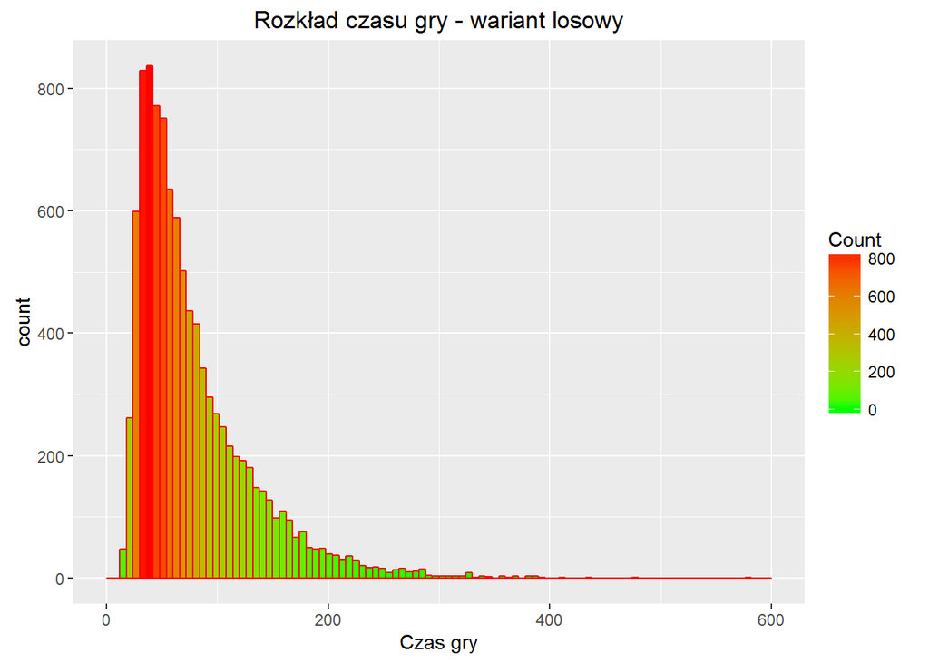

```r
dane0<-melt(random.resulst)
g <- ggplot(dane0,aes(x=value))
g <- g + geom_histogram(aes(fill=..count..),col="red",breaks=seq(0,600,6))+
  scale_fill_gradient("Count", low = "green", high = "red")
g<-g+labs(list(title="Rozkład czasu gry - wariant losowy", x="Czas gry"))
g
```

> Przetrenowanie modelu

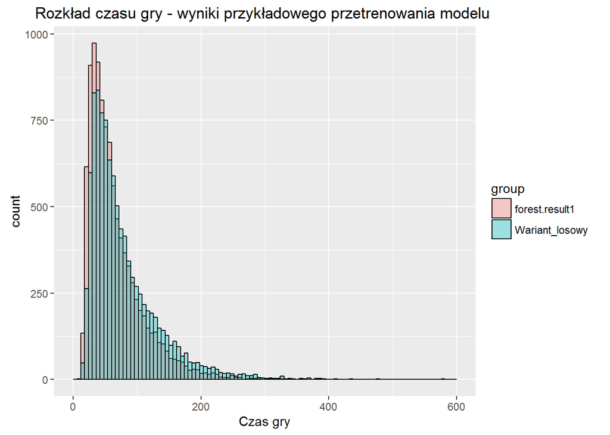

```r
load("C:/Users/Key/Downloads/forest.result1.rda")
dane1<-melt(forest.result1)
dane0$group <- 'Wariant_losowy'
dane1$group <- 'forest.result1'
dane01 <- rbind(dane0, dane1)
p <- ggplot(dane01, aes(value, group=group,col=group, fill=group)) +
  geom_histogram(alpha=0.35, aes(fill=group),col="black", breaks=seq(0,600,6),  position = 'identity')
p<-p+labs(list(title="Rozkład czasu gry - wyniki przykładowego przetrenowania modelu ", x="Czas gry"))
p
```

> Porównanie

Analiza boxplotów potwierdza, że przyjęta przez nas strategia, skraca czas przeprowadzania gry - obserwujemy zmniejszenie wszystkich podstawowych statystyk w porównaniu do wariantu losowego, jednakże nie uzyskałyśmy zadawalających wyników z przetrenowania tego modelu 40 razy.

```r
load("C:/Users/Key/Downloads/last.results.rda")
load("C:/Users/Key/Downloads/forest.result2.rda")
load("C:/Users/Key/Downloads/forest.result3.rda")
Wyniki<-rep(c("random.result","forest.result1" ,"forest.result2","forest.result3"), each=10000 )
Czas_gry<-c(random.resulst,forest.result1,forest.result2,forest.result3)
b<-data.frame(Wyniki,Czas_gry)
c<-ggplot(b, aes(x=Wyniki, y = log(Czas_gry,10), fill=Wyniki)) +
  geom_boxplot()+
  stat_summary(fun.y=mean, geom="point", shape=1, size=1)
ggplotly()
```

[interactive chart not shown]

```r
podsumowanie.faza1 <- data.frame(cbind(summary(random.resulst),summary(forest.result1),summary(forest.result2),summary(forest.result3)))
names(podsumowanie.faza1)[1]<-paste("Wariant_losowy")
names(podsumowanie.faza1)[2]<-paste("Iprzetrenowanie")
names(podsumowanie.faza1)[3]<-paste("IIprzetrenowania")
names(podsumowanie.faza1)[4]<-paste("IIIprzetrenowania")
kable(podsumowanie.faza1)
```

|  | Wariant_losowy | Iprzetrenowanie | IIprzetrenowania | IIIprzetrenowania |
| --- | --- | --- | --- | --- |
| Min. | 13.00 | 11.00 | 8.00 | 11.0 |
| 1st Qu. | 42.00 | 36.00 | 32.00 | 34.0 |
| Median | 63.00 | 54.00 | 49.00 | 52.0 |
| Mean | 79.14 | 65.66 | 60.58 | 64.5 |
| 3rd Qu. | 101.00 | 83.00 | 77.00 | 81.0 |
| Max. | 580.00 | 356.00 | 413.00 | 474.0 |

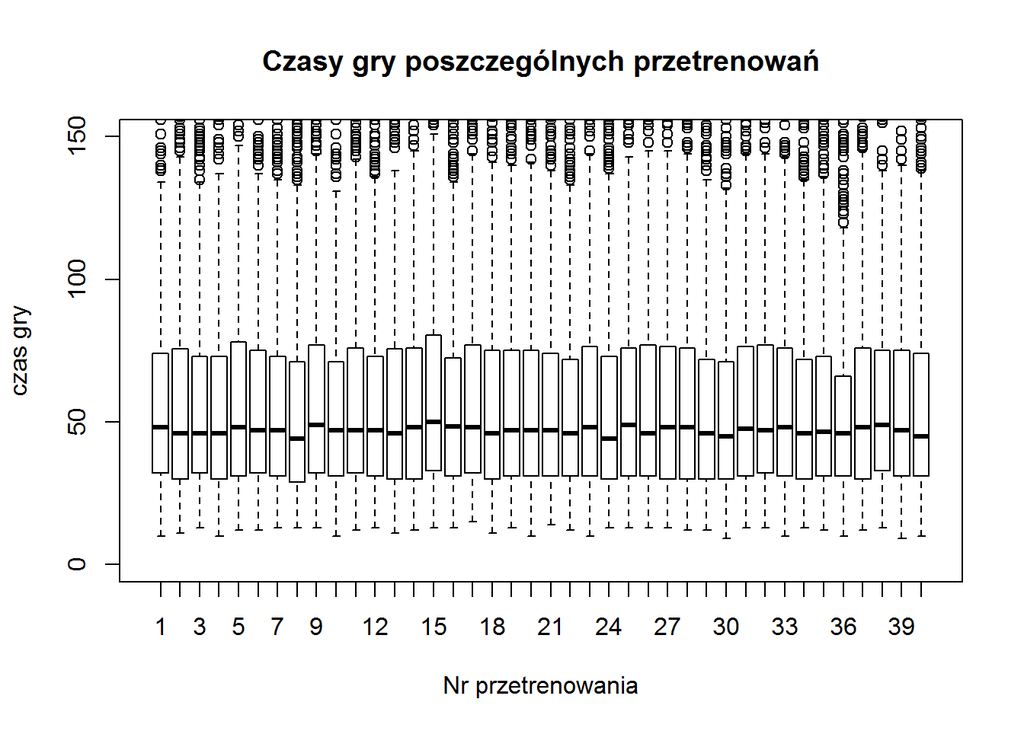

```r
boxplot(last.results,  main = "Czasy gry poszczególnych przetrenowań", xlab = "Nr przetrenowania",ylab = "czas gry", ylim = c(0, 150))
```

```r
podsumowanie<-data.frame(cbind(summary(random.resulst)))
names(podsumowanie)[1]<-paste("losowy")
for (i in 2:41){
  podsumowanie[[i]]  <- summary(last.results[[i-1]])
  names(podsumowanie)[i]<-paste("nr",i-1)
}
kable(podsumowanie[,c(1,4,20,40)])
```

|  | losowy | nr 3 | nr 19 | nr 39 |
| --- | --- | --- | --- | --- |
| Min. | 13.00 | 13.00 | 13.00 | 9.00 |
| 1st Qu. | 42.00 | 32.00 | 31.00 | 31.00 |
| Median | 63.00 | 46.00 | 47.00 | 47.00 |
| Mean | 79.14 | 58.33 | 59.64 | 57.21 |
| 3rd Qu. | 101.00 | 73.00 | 75.00 | 75.00 |
| Max. | 580.00 | 280.00 | 416.00 | 341.00 |

## Kod

> Wczytanie potrzebnych pakietów

```r
library(randomForest) #uczenie maszynowe
```

> Deklaracja stalych globalnych

```r
move = c(0, 0, 0, 0, 0, 0, 0)
animals = c("horse", "cow", "bdog", "pig", "sheep", "sdog", "rabbit")
#stan stada gracza (w kolejności cenowej malejąco)
stock.status = c(0, 0, 0, 0, 0, 0, 0)
names(stock.status) = animals
#liczba zwierząt w pudełku
max.stock = c(6, 12, 2, 20, 24, 4, 60)
names(max.stock) = animals
#obie kostki
die1 = c("rabbit", "rabbit", "rabbit", "rabbit", "rabbit", "rabbit", "sheep", "sheep", "sheep", "pig", "cow", "wolf")
die2 = c("rabbit", "rabbit", "rabbit", "rabbit", "rabbit", "rabbit", "sheep", "sheep", "pig", "pig", "horse", "fox")
#ceny zwierzat
prices.sorted = c(72, 36, 36, 12, 6, 6, 1)
names(prices.sorted) = animals
```

> Możliwe wymiany

> Funkcja rekurencyjna tworząca macierze wymian. Działa w następujący sposób: najpierw odpala się najpierw dla najwyższej ceny, patrzy ile najdroższych zwierząt jest w stanie kupić, następnie odpala się dla każdej kupionej liczby najdroższych zwierząt, ale już bez najwyższej ceny, a w końcu dochodzi do samych królików, gdzie zwraca pre_moves, które narastało przy wcześniejszych odpaleniach

```r
split = function(n.rabbits, prices.sorted, pre_moves=c(), moves=c()) {
  ratio = floor(n.rabbits/prices.sorted[1])
  #Warunek końcowy
  if(length(prices.sorted) == 1){
    return(c(pre_moves, ratio))
  }
  for(i in 0:ratio){
    #Dopisywany jest tutaj kolejny wiersz macierzy ruchów
    moves = rbind(moves, split(n.rabbits - i*prices.sorted[1],
                               prices.sorted[-1],
                               c(pre_moves, i),
                               moves))
  }
  return(unique(moves))
}
```

> Tworzenie listy zawierającejnazwy zwierząt i przypisane im macierze wszystkich wymian: Dla każdego zwierzęcia odpalana jest funkcja split, a wszystko to zapisuje się w dwóch listach, dzięki czemu tworzy się to tylko raz dla wszytkich gier.

```r
#lista możliwych zamian małych zwierząt na jedno większe
to.big.animal = list()
#lista możliwych zamian dużego zwierzęcia na mniejsze
to.small.animals = list()
for(i in animals){
  to.big.animal[[i]] = -split(prices.sorted[[i]], prices.sorted)
  to.big.animal[[i]][, which(names(prices.sorted) == i)] = 1
  #Wyrzucanie przypadków, że wymianiamy jedno zwierzę na nic
  #(były takie gdy w funkcji split wychodziła np. wymiana konia na konia)
  to.big.animal[[i]] = to.big.animal[[i]][rowSums(to.big.animal[[i]]) != 1, , drop=F]
  to.small.animals[[i]] = -to.big.animal[[i]]
}
#to.big.animal wyglada teraz tak: zwierzęta, które oddajemy są na minusie, a te, które otrzymujemy na plusie
```

> Generowanie wszystkich możliwych ruchów

```r
moves.generation = function(stock.status){
  n.rabbits = sum(stock.status * prices.sorted)
  possible.moves = c()
  for(i in 1:length(prices.sorted)){
    if(n.rabbits >= prices.sorted[i]){
      possible.moves = rbind(possible.moves, to.big.animal[[names(prices.sorted[i])]])
    }
  }
  if(!is.null(dim(possible.moves)) && dim(possible.moves)[1] > 0){
    #Sprawdzanie czy mamy wystarczająco dużo zwierząt w stocku, żeby dokonać wumiany.
    #Nie znalazłam lepszego sposobu na dodanie stock.status do każdego wiersza
    #zamiast do każdej kolumny niż transponowanie macierzy dwukrotnie
    enough.animals = rowMeans(t(t(possible.moves) + stock.status) >= 0)
    #Wszystkie wymiany, na które nie mamy zwierząt są odrzucane
    possible.moves = possible.moves[enough.animals == 1, , drop=F]
  }
  for(i in names(stock.status)){
    if(stock.status[[i]] != 0){
      possible.moves = rbind(possible.moves, to.small.animals[[i]])
    }
  }
  possible.moves = unique(possible.moves)
  if(!is.null(dim(possible.moves)) && dim(possible.moves)[1] > 0){
    #Sprawdzenie czy ruch jest możliwy ze względu na liczbę zwierząt w całej grze
    future.states = t(t(possible.moves) + stock.status)
    #Sprawdzamy czy średnia wyrażeń logicznych w każdym rzędzie jest równa 1,
    #bo interesują nas tylko te ruchy, na które starczy wszystkich zwierząt
    possible.states = rowMeans(t(t(future.states) <= max.stock)) == 1
    #Bierzemy tylko te ruch, które są możliwe ze wzglęgu na maksymalną liczbę zwierząt
    possible.moves = as.matrix(possible.moves[possible.states, ])
    #Dorzucamy brak ruchu jako możliwość
    possible.moves = rbind(possible.moves, c(0, 0, 0, 0, 0, 0, 0))
  }
  return(possible.moves)
}
```

> STRATEGIA I (Domink Ambroziak, Anna Dymowska, Adam Król) [kliknij po więcej informacji o strategii](https://github.com/pbiecek/ProgramowanieWizualizacja/blob/master/MIMUW_2017/Projekty/Faza1/Faza1-Amb%2CDym%2CKrol.Rmd)

```r
strategy1.to.bigger.animal=function(stock.status,max.stock, prices.sorted,i, new.sequence){

  move[new.sequence[i]]=1
  stock.status[new.sequence[i]]<-1
  max.stock[new.sequence[i]]<-max.stock[new.sequence[i]]-1
  dosplaty<-prices.sorted[new.sequence[i]]
  j<-(i-1)
  while(dosplaty>0){
    if (stock.status[new.sequence[j]]>=1){#sprzedaję zwierzęta kolejno od największych
      dosplaty<-(dosplaty-prices.sorted[new.sequence[j]])
      move[new.sequence[j]]=move[new.sequence[j]]-1
      stock.status[new.sequence[j]]<-stock.status[new.sequence[j]]-1
      max.stock[new.sequence[j]]<-max.stock[new.sequence[j]]+1
    }
    if (stock.status[new.sequence[j]]==0){
      j<-(j-1)
    }
  }

  return(c(move))
}
```

```r
strategy1.to.smaller.animal=function(stock.status, max.stock, prices.sorted,i, new.sequence){
  move[new.sequence[i]]=move[new.sequence[i]]-1
  stock.status[new.sequence[i]]<-stock.status[new.sequence[i]]-1
  max.stock[new.sequence[i]]<-max.stock[new.sequence[i]]+1
  for (j in (i-1):1){
    move[new.sequence[j]]=move[new.sequence[j]]+1
    stock.status[new.sequence[j]]<-stock.status[new.sequence[j]]+1
    max.stock[new.sequence[j]]<-max.stock[new.sequence[j]]-1
  }
  return(c(move))
}
```

```r
strategy1.move=function(stock.status, max.stock, prices.sorted){
  new.sequence=c(7,5,4,2,3,1,6)
  for (i in 6:2){
    if (stock.status[new.sequence[i]]==0){         #sprawdzam, czy nie mam i-tego zwierzęcia
      #sprawdzam, czy mogę kupić i-te zwierzę
      if((sum(stock.status[new.sequence[1:(i-1)]]*prices.sorted[new.sequence[1:(i-1)]]))>=prices.sorted[new.sequence[i]]){
        move=strategy1.to.bigger.animal(stock.status, max.stock, prices.sorted,i, new.sequence)
        break
      }
    }
  }
  for(i in 6:2){
    if (stock.status[new.sequence[i]]>1){  #sprzedawanie drugiego zwierzęcia
      if (prod(stock.status[new.sequence[i:6]])>0){
        move=strategy1.to.smaller.animal(stock.status, max.stock, prices.sorted,i, new.sequence)
      }
    }
  }
  return(move)
}
```

> STRATEGIA II (Marianna Dzik, Piotr Radziński) [kliknij po więcej informacji o strategii](https://github.com/pbiecek/ProgramowanieWizualizacja/blob/master/MIMUW_2017/Projekty/Faza1/Superfarmer_M_Dzik_P_Radzinski.html)

```r
strategy2.to.bigger.animal=function(stock.status,prices.sorted,animal){
  new.sequence2=c(7,6,5,4,2,3,1)
  i<-which(names(stock.status[new.sequence2])==animal)
  if((sum(stock.status[new.sequence2[1:(i-1)]]*prices.sorted[new.sequence2[1:(i-1)]]))>=prices.sorted[new.sequence2[i]]){
    move[new.sequence2[i]]=1
    stock.status[new.sequence2[i]]<-stock.status[new.sequence2[i]]+1
    dosplaty<-prices.sorted[new.sequence2[i]]
    j<-(i-1)
    while(dosplaty>0){
      if (stock.status[new.sequence2[j]]>=1){#sprzedaję zwierzęta kolejno od największych
        dosplaty<-(dosplaty-prices.sorted[new.sequence2[j]])
        move[new.sequence2[j]]=move[new.sequence2[j]]-1
        stock.status[new.sequence2[j]]<-stock.status[new.sequence2[j]]-1
      }
      if (stock.status[new.sequence2[j]]==0){
        j<-(j-1)
      }
    }
  }
  return(c( move))
}
```

```r
#funkcja zamieniająco króliki na zwierzę animal
strategy2.change.rabbit=function(stock.status,prices.sorted, animal){
  move[which(names(stock.status)==animal)]=move[which(names(stock.status)==animal)]+1
  move[which(names(stock.status)=="rabbit")]<-move[which(names(stock.status)=="rabbit")]-prices.sorted[[animal]]
  return(c(move))
}
```

```r
strategy2.animal1.to.smaller.animal2=function(stock.status,prices.sorted,animal1, animal2){
  move[which(names(stock.status)==animal1)]=move[which(names(stock.status)==animal1)]-1
  move[which(names(stock.status)==animal2)]=move[which(names(stock.status)==animal2)]+(prices.sorted[[animal1]]/prices.sorted[[animal2]])
  return(c(move))
}
```

```r
strategy2.change=function(stock.status,prices.sorted){
  property=sum(stock.status*prices.sorted)
  ruch=0
  move=c(0,0,0,0,0,0,0)
  if (stock.status[["horse"]]==0){
    if(property>=72 && ruch==0){
      move=strategy2.to.bigger.animal(stock.status,prices.sorted,"horse")
      ruch=1
    }else if(stock.status[["sdog"]]==0 && stock.status[["rabbit"]]>9 && ruch==0){
      move=strategy2.change.rabbit(stock.status,prices.sorted, "sdog")
      ruch=1
    }else if(stock.status[["sdog"]]==1 && stock.status[["rabbit"]]>25 && ruch==0){
      move=strategy2.change.rabbit(stock.status,prices.sorted, "sdog")
      ruch=1
    }else if(stock.status[["rabbit"]]<27 && stock.status[["pig"]]>0 && ruch==0){
      move=strategy2.animal1.to.smaller.animal2(stock.status,prices.sorted, "pig","rabbit")
      ruch=1
    }else if(stock.status[["rabbit"]]<33 && stock.status[["sheep"]]>0 && ruch==0){
      move=strategy2.animal1.to.smaller.animal2(stock.status,prices.sorted, "sheep","rabbit")
      ruch=1
    }else if(stock.status[["rabbit"]]==0 && stock.status[["sdog"]]>0 && ruch==0){
      move=strategy2.animal1.to.smaller.animal2(stock.status,prices.sorted, "sdog","rabbit")
      ruch=1
    }else if(stock.status[["rabbit"]]<=45 && stock.status[["rabbit"]]>39 && stock.status[["sheep"]]<23 && ruch==0){
      move=strategy2.change.rabbit(stock.status,prices.sorted, "sheep")
      ruch=1
    }else if(stock.status[["rabbit"]]>=46 && stock.status[["pig"]]<20 && ruch==0){
      move=strategy2.change.rabbit(stock.status,prices.sorted, "pig")
      ruch=1
    }

  } else if(stock.status[["horse"]]==1){
    if(property>=144 && ruch==0){
      move=strategy2.to.bigger.animal(stock.status,prices.sorted,"horse")
      ruch=1
    }else if(property>=127 && ruch==0){
      if(stock.status[["rabbit"]]==0 && stock.status[["cow"]]>1 && ruch==0){
        move=strategy2.animal1.to.smaller.animal2(stock.status,prices.sorted,"cow", "rabbit")
        ruch=1
      }else if(stock.status[["sheep"]]==0 && stock.status[["cow"]]>1 && ruch==0){
        move=strategy2.animal1.to.smaller.animal2(stock.status,prices.sorted,"cow", "sheep")
        ruch=1
      }else if(stock.status[["pig"]]==0 && stock.status[["cow"]]>1 && ruch==0){
        move=strategy2.animal1.to.smaller.animal2(stock.status,prices.sorted,"cow", "pig")
        ruch=1
      }else if(stock.status[["rabbit"]]==0 && stock.status[["pig"]]>1 && ruch==0){
        move=strategy2.animal1.to.smaller.animal2(stock.status,prices.sorted,"pig", "rabbit")
        ruch=1
      }else if(stock.status[["sheep"]]==0 && stock.status[["pig"]]>1 && ruch==0){
        move=strategy2.animal1.to.smaller.animal2(stock.status,prices.sorted,"pig", "sheep")
        ruch=1
      }else if(stock.status[["rabbit"]]==0 && stock.status[["sheep"]]>1 && ruch==0){
        move=strategy2.animal1.to.smaller.animal2(stock.status,prices.sorted,"sheep", "rabbit")
        ruch=1
      }else if(stock.status[["sheep"]]==0&&stock.status[["rabbit"]]>6&& ruch==0){
        move=strategy2.change.rabbit(stock.status,prices.sorted, "sheep")
        ruch=1
      }else if(stock.status[["pig"]]==0 && ruch==0){
        move=strategy2.to.bigger.animal(stock.status,prices.sorted,"pig")
        ruch=1
      }else if(stock.status["cow"]==0 && ruch==0){
        move=strategy2.to.bigger.animal(stock.status,prices.sorted,"cow")
        ruch=1
      }
    }else if(property<127 && ruch==0){
      if(stock.status[["sdog"]]==0 && stock.status[["rabbit"]]>9 && ruch==0){
        move=strategy2.change.rabbit(stock.status,prices.sorted, "sdog")
        ruch=1
      }else if(stock.status[["rabbit"]]==0 && stock.status[["sdog"]]>0 && ruch==0){
        move=strategy2.animal1.to.smaller.animal2(stock.status,prices.sorted, "sdog","rabbit")
        ruch=1
      }else if(stock.status[["sheep"]]==0 && stock.status[["rabbit"]]>15 && ruch==0){
        move=strategy2.change.rabbit(stock.status,prices.sorted, "sheep")
        ruch=1
      }else if(stock.status[["sheep"]]>0 && stock.status[["rabbit"]]>20 && stock.status[["pig"]]==0 &&ruch==0){
        move=strategy2.change.rabbit(stock.status,prices.sorted, "pig")
        ruch=1
      }
    }
  }else if(stock.status[["horse"]]>1 && ruch==0){
    move[which(names(stock.status)=="horse")]=move[which(names(stock.status)=="horse")]-1
    move[which(names(stock.status)=="cow")]=move[which(names(stock.status)=="cow")]+1
    move[which(names(stock.status)=="pig")]=move[which(names(stock.status)=="pig")]+2
    move[which(names(stock.status)=="sheep")]=move[which(names(stock.status)=="sheep")]+1
    if(stock.status[["rabbit"]]<54){
      move[which(names(stock.status)=="rabbit")]=move[which(names(stock.status)=="rabbit")]+6
    }else{
      move[which(names(stock.status)=="sheep")]=move[which(names(stock.status)=="sheep")]+1
    }
    ruch=1
  }
  return(c(move))
}
```

> Sposób wybrania ruchu

```r
choose.move = function(way, possible.moves, model = NULL, stock.status){
  max.stock = c(6, 12, 2, 20, 24, 4, 60)
  if(way == "random"){
    #Losowy wybór ruchu
    number.moves = nrow(possible.moves)
    move = possible.moves[sample(1:number.moves, 1), ]
    return(move)
  } else if(way == "rf") {
    #Wybór w oparciu o model random forest
    df1 = matrix(stock.status, nrow = nrow(possible.moves), ncol = 7, byrow = T)
    df1 = cbind(df1, possible.moves)

    n.types.after = rowSums((df1[, 1:7] + df1[, 8:14])[, c(1, 2, 4, 5, 7)] > 0)
    n.types.before = rowSums((df1[, 1:7])[, c(1, 2, 4, 5, 7)] > 0)
    #(Dorzucamy te same kolumny co w funkcji "forest.training.and.results",
    #żeby random forest miał tyle samo zmiennych)
    #Żeby modelowi łatwiej było się uczyć oraz przewidywać dorzucamy kolumny mówiące
    #ile rodzajów zwierząt potrzebnych do wygranej mieliśmy,
    #ile będziemy mieć po ruchu i jaka jest różnica
    df1 = cbind(df1, n.types.before)
    df1 = cbind(df1, n.types.after)
    df1 = cbind(df1, (n.types.after - n.types.before))
    colnames(df1) = c("X1", "X2", "X3", "X4", "X5", "X6", "X7", "X8", "X9",
                      "X10", "X11", "X12", "X13", "X14", "X16", "X17", "X18")
    pred = predict(model, df1)
    #Bierzemy ruch, który otrzymał od naszego modelu najmniejszą przewidywaną liczbę ruchów do wygranej
    which.move = sample(which(pred == min(pred)), 1)
    #Jako, że czasami występują dwa ruchy o tej samej predykcji, to bierzemy losowy z nich
    move = possible.moves[which.move, ]
    return(move)
  } else if (way == "strategy1") {
    max.stock1=max.stock-stock.status
    names(max.stock1) = animals
    move=strategy1.move(stock.status, max.stock1, prices.sorted)
    return(move)
  }else if(way=="strategy2") {
    move=strategy2.change(stock.status, prices.sorted)
    return(move)
  }
}
```

> Powiększanie stada po rzucie

```r
reproduction = function(die1.result, die2.result, stock.status,max.stock){
  if(die1.result == die2.result){
    stock.status[[die1.result]] = min(floor(stock.status[[die1.result]] + (stock.status[[die1.result]]+2)/2), max.stock[[die1.result]])
  } else if(die1.result == "wolf" && die2.result == "fox"){
    if(stock.status[["bdog"]] == 0){
      stock.status[["rabbit"]] = 0
      stock.status[["sheep"]] = 0
      stock.status[["pig"]] = 0
      stock.status[["cow"]] = 0
    } else {
      stock.status[["bdog"]] = stock.status[["bdog"]] - 1
    }
    if(stock.status[["sdog"]] == 0){
      stock.status[["rabbit"]] = 0
    } else {
      stock.status[["sdog"]] = stock.status[["sdog"]] - 1
    }
  } else if(die1.result == "wolf"){
    if(stock.status[["bdog"]] == 0){
      stock.status[["rabbit"]] = 0
      stock.status[["sheep"]] = 0
      stock.status[["pig"]] = 0
      stock.status[["cow"]] = 0
    } else {
      stock.status[["bdog"]] = stock.status[["bdog"]] - 1
    }
    stock.status[[die2.result]] = min(floor(stock.status[[die2.result]] + (stock.status[[die2.result]]+1)/2), max.stock[[die2.result]])

  } else if(die2.result == "fox"){
    if(stock.status[["sdog"]] == 0){
      stock.status[["rabbit"]] = 0
    } else {
      stock.status[["sdog"]] = stock.status[["sdog"]] - 1
    }
    stock.status[[die1.result]] = min(floor(stock.status[[die1.result]] + (stock.status[[die1.result]]+1)/2), max.stock[[die1.result]])
  } else {
    stock.status[[die1.result]] = min(floor(stock.status[[die1.result]] + (stock.status[[die1.result]]+1)/2), max.stock[[die1.result]])
    stock.status[[die2.result]] = min(floor(stock.status[[die2.result]] + (stock.status[[die2.result]]+1)/2), max.stock[[die2.result]])
  }
  return(stock.status)
}
```

> Funkcja zmieniająca stan stada

```r
change = function(move, stock.status){
  stock.status + move
}
```

> Funkcja sprawdzająca, czy został spełniony warunek wygranej (Gracz ma conajmniej jedno zwierzę z każdego gatunku)

```r
win = function(stock.status){
  min(stock.status[c(1, 2, 4, 5, 7)]) > 0
}
```

> Pojedyncza gra

```r
play = function(nrows = 0, way, model = NULL, save.moves = T){
  turns = 0
  tmp.data = matrix(data=NA, nrow=1000, ncol=14)
  while(!win(stock.status)){
    turns = turns + 1
    nrows = nrows +1
    # main code for play
    possible.moves = moves.generation(stock.status)
    if(!is.null(dim(possible.moves)) && dim(possible.moves)[1] > 0){
      move = choose.move(way, possible.moves, model, stock.status)
      if(save.moves){
        tmp.data[turns, ] = c(stock.status, move)
      }
      stock.status = change(move, stock.status)
    }
    # check if win after move
    if(win(stock.status)){
      #turns.to.end = turns:1
      #one.generation[(nrows - turns + 1):nrows, ] <<- cbind(tmp.data[1:turns, ], turns.to.end)
      return(list(nrows, turns, tmp.data))
    }
    # roll dice (why not at the beginning of the move?)
    die1.result = sample(die1, 1)
    die2.result = sample(die2, 1)
    stock.status = reproduction(die1.result, die2.result, stock.status,max.stock)
  }
  #turns.to.end = turns:1
  #one.generation[(nrows - turns + 1):nrows, 15] <<- turns.to.end
  return(list(nrows, turns, tmp.data))
}
```

> Generowanie danych do uczenia maszynowego

```r
generate.data = function(way, model = NULL, max.nrows = 5e4){
  one.generation = data.frame(matrix(NA, nrow = max.nrows, ncol = 15))
  results = c()
  nrows = 0
  for(i in 1:1e5){
    if(nrows >= max.nrows){
      return(list(results, one.generation[complete.cases(one.generation), ]))
    }
    play.data = play(nrows, way, model)
    nrows = play.data[[1]]
    results[i] = play.data[[2]]
    turns = results[i]
    tmp.data = play.data[[3]]
    turns.to.end = turns:1
    one.generation[(nrows - turns + 1):nrows, ] <- cbind(tmp.data[1:turns, ], turns.to.end)
    cat(turns, " ")
  }
  return(list(results, one.generation[complete.cases(one.generation), ]))
}
```

> Funkcja trenująca model oraz generująca ostateczne wyniki

```r
forest.training.and.results = function(){
  forest.results = list()
  random.data = generate.data(way="random")
  random.result = random.data[[1]]
  random.data.to.learn = random.data[[2]]
  strategy1.data = generate.data(way="strategy1")
  strategy1.result = strategy1.data[[1]]
  strategy1.data.to.learn = strategy1.data[[2]]
  strategy2.data = generate.data(way="strategy2")
  strategy2.result = strategy2.data[[1]]
  strategy2.data.to.learn = strategy2.data[[2]]
  data = rbind(random.data.to.learn, strategy1.data.to.learn, strategy2.data.to.learn)

  for(i in 1:40){
    n.types.after = rowSums((data[, 1:7] + data[, 8:14])[, c(1, 2, 4, 5, 7)] > 0)
    n.types.before = rowSums((data[, 1:7])[, c(1, 2, 4, 5, 7)] > 0)
    data$X16 = n.types.before
    data$X17 = n.types.after
    data$X18 = n.types.after - n.types.before
    rf1 = randomForest(as.matrix(data[, -15]), data[, 15], ntree=25, mtry=17)
    forest.data = generate.data(way = "rf", rf1)
    forest.results[[i]] = forest.data[[1]]
    data = forest.data[[2]]
  }
  return(forest.results)
}
```